# Fallstudie: Robinson Club

Piet

15 2 2020

# Zielformulierung: Ist die Einführung von Bionahrung beim Robinson Club aus betriebswirtschaftlicher Sicht strategisch sinvoll?

## Hypothesen:

1. Personen mit Kindern bevorzugen Bionahrung eher als Personen ohne Kinder.
2. Robinson G ̈aste sind bereit fu ̈r Bionahrung einen Aufschlag zu zahlen.
3. Bionahrung besitzt das Potenzial ROBINSON als Marke zu st ̈arken.

## Packages importieren

```r
install.packages('tidyverse')
library(tidyverse)
install.packages('dplyr')
library(dplyr)

install.packages('data.table')
library(data.table)
install.packages('VIM')
library(VIM)
install.packages('class')
library(class)

install.packages("factoextra")
library(factoextra)
```

## Daten importieren und schnellen Überblick verschaffen

```r
fragebogen = read.csv('fallstudie.csv')

sum(is.na(fragebogen))
```

```
## [1] 2867
```

```r
str(fragebogen)
```

```
## 'data.frame':    219 obs. of  144 variables:
##  $ ID         : int  1 2 3 4 5 6 7 8 9 10 ...
##  $ Ort        : int  1 1 1 1 1 1 1 1 1 1 ...
##  $ f1         : int  2 1 6 9 9 3 2 7 2 6 ...
##  $ f2         : int  3 2 3 2 2 2 1 2 0 3 ...
##  $ f3_1       : int  3 3 1 2 2 4 2 1 2 2 ...
##  $ f3_2       : int  2 2 1 2 1 2 2 1 1 1 ...
##  $ f3_3       : int  1 2 1 1 1 3 2 1 1 1 ...
##  $ f3_4       : int  1 2 1 NA 2 NA 2 NA 1 1 ...
##  $ f3_5       : int  1 1 2 2 2 2 2 1 3 3 ...
##  $ f3_6       : int  1 1 2 2 2 2 2 1 3 3 ...
##  $ f3_7       : int  2 2 1 2 2 2 2 2 4 3 ...
##  $ f3_8       : int  2 2 1 2 2 2 2 1 2 1 ...
##  $ f3_9       : int  2 2 1 4 2 3 1 NA 2 1 ...
##  $ f3_10      : int  3 2 1 4 2 4 2 NA NA 2 ...
```

[output cut: 86 more lines]

```r
head(fragebogen)
```

```
##   ID Ort f1 f2 f3_1 f3_2 f3_3 f3_4 f3_5 f3_6 f3_7 f3_8 f3_9 f3_10 f3_11
## 1  1   1  2  3    3    2    1    1    1    1    2    2    2     3     2
## 2  2   1  1  2    3    2    2    2    1    1    2    2    2     2     1
## 3  3   1  6  3    1    1    1    1    2    2    1    1    1     1     1
## 4  4   1  9  2    2    2    1   NA    2    2    2    2    4     4     2
## 5  5   1  9  2    2    1    1    2    2    2    2    2    2     2     2
## 6  6   1  3  2    4    2    3   NA    2    2    2    2    3     4     2
##   f3_txt_val f3_txt f4_1 f4_2 f4_3 f4_4 f4_5 f4_6 f4_7 f4_8 f4_9 f4_10 f4_11
## 1         NA           1    1    3    3    3    6    3    3    1     3     1
## 2         NA           3    4    3    5    5    2    2    1    2     3     2
## 3         NA           2    4    6    6    6    6    1    1    1     6     3
## 4         NA           3    3    7    3    7    7    4    1    1     5     1
## 5         NA           2    2    5    3    5    5    2    2    2     2     1
## 6         NA           3    3    5    4    6    3    3    2    2     6     1
##   f4_12 f4_13 f4_14 f4_txt_val f4_txt f5_1 f5_2 f5_3 f5_4 f5_5 f5_6 f5_7 f5_8
```

[output cut: 83 more lines]

## CLEANING

### Umgang mit fehlenden Werten

#### Drei verschiedene Arten von fehlenden Daten

1. Missing completely at random (MCAR): Das Fehlen der Daten steht in keiner Beziehung zu den anderen Daten. Wenn man vorhersagen kann, welche Daten fehlen, dann kann man MCAR ausschließen. Das fehlen der Daten ist somit komplett zufällig.
2. Missing at random (MAR): Die Idee hinter dieser Art von fehlenden Daten ist, dass wir die fehlenden Daten vorhersagen können anhand des Datensets.
3. Missing not at random (nonignorable) In diesem Fall können wir keine Aussage oder Prognose für die fehlenden Werte machen. Es ist weder MAR noch MCAR.

#### Drei verschiedene Methoden mit fehlenden Daten umzugehen:

1.FEHLENDE DATEN LÖSCHEN  
Wenn NA’s nur wenige (max 0,5 %) von Erhebung macht droppen Sinn, da einfach und Testergebnis nicht zu sehr verzerrt wird. na.omit() wäre der Code-Snippet. Dabei würde wenn überhaupt eine reihenweise Löschung Sinn machen, da wir für die Analyse eines Befragten die ganzen Werte brauchen. Dies führt allerdings zur Löschung des komplette Datensets. Somit kommt diese Methode für uns nicht in Frage.

2.FEHLENDEN DATEN MIT TEST STATISTIKEN FÜLLEN Wenn mean() dann darf der prozentuale Anteil von NA’s auch nicht so hoch sein (kann man hier einfach den Default Alpha Value nehmen?) Es verringert die Varianz der Erhebungsdaten, da diese geglättet werden durch das arithemtische Mittel. Extreme Ausreißer können den mean() zu stark beeinflussen und das Ergebniss verzerren. Hier sind die Zahlen  
kategorisch vorgegeben, somit kann es keine größeren Ausreißer geben.

3.FEHLENDE DATEN MIT MACHINE LEARNING ALGORITHMEN BESTIMMEN Ein Beispiel für ein einfach zu implementierenden Algorithmus wäre K-Means oder auch KNN genannt. Idee hinter KNN: Die fehlenden Werte können mit den Werte die diesem Wert in einem zweidimensionalen Koordinatensystem am nähesten Liegen ermittelt werden. Kann sehr viel genauer sein als ein einfache means() und es ist sehr sensitiv was Outliers anbelangt. Allerdings für uns könnten diese Methodik sehr interessant sein, da wir keine Ausreißer im klassischen Sinne haben können, da die Range schon vorgegeben ist. Dieser Algorithmus kann für stetig und diskrete Daten genutzt werden.

## Welche Spalten sind von NA’s betroffen?

```r
contains_any_na = sapply(fragebogen, function(x) any(is.na(x)))
column_names_na = names(fragebogen)[contains_any_na]

## df das anzeigt wie viel Prozent NA pro Spalte vorhanden sind
perc_na = sapply(fragebogen, function(x) sum(is.na(x))/count(fragebogen))
perc_na = as.data.frame(perc_na)
perc_na
```

```
##   ID.n Ort.n       f1.n f2.n    f3_1.n     f3_2.n     f3_3.n     f3_4.n
## 1    0     0 0.02739726    0 0.0456621 0.02283105 0.00913242 0.08675799
##       f3_5.n     f3_6.n     f3_7.n     f3_8.n     f3_9.n  f3_10.n    f3_11.n
## 1 0.01826484 0.01369863 0.01826484 0.00456621 0.06392694 0.173516 0.02283105
##   f3_txt_val.n f3_txt.n     f4_1.n     f4_2.n     f4_3.n     f4_4.n    f4_5.n
## 1    0.9497717        0 0.01826484 0.02283105 0.05479452 0.05022831 0.1050228
##       f4_6.n     f4_7.n     f4_8.n     f4_9.n    f4_10.n    f4_11.n    f4_12.n
## 1 0.03652968 0.01826484 0.01369863 0.00913242 0.05479452 0.01369863 0.00456621
##      f4_13.n    f4_14.n f4_txt_val.n f4_txt.n     f5_1.n     f5_2.n     f5_3.n
## 1 0.01826484 0.02739726    0.9726027        0 0.00456621 0.00456621 0.01369863
##       f5_4.n f5_5.n     f5_6.n     f5_7.n     f5_8.n     f5_9.n    f5_10.n
## 1 0.00456621      0 0.00913242 0.02283105 0.03196347 0.01369863 0.02739726
##      f5_11.n f5_txt_val.n f5_txt.n     f6_1.n     f6_2.n     f6_3.n    f6_4.n
## 1 0.05479452            1        0 0.00913242 0.01826484 0.06392694 0.2511416
##      f6_5.n     f6_6.n    f6_7.n    f6_8.n     f6_9.n f6_txt.n f7_txt.n
## 1 0.3515982 0.05479452 0.6484018 0.6757991 0.07305936        0        0
##         f8.n       f9.n    f10_1.n    f10_2.n f11_1.n f11_2.n f11_3.n f11_4.n
## 1 0.00456621 0.00456621 0.02283105 0.07762557       0       0       0       0
##   f11_5.n f11_6.n    f11_7.n f11_8.n f11_9.n f11_10.n f11_txt.n    f12_1.n
## 1       0       0 0.00456621       0       0        0         0 0.00456621
##      f12_2.n    f12_3.n    f12_4.n    f12_5.n    f12_6.n    f12_7.n    f12_8.n
## 1 0.00456621 0.00456621 0.00913242 0.00456621 0.00456621 0.00456621 0.00456621
##      f12_9.n    f13_1.n    f13_2.n    f13_3.n f14_txt.n    f15_1.n    f15_2.n
## 1 0.00456621 0.00456621 0.00456621 0.00456621         0 0.05936073 0.05022831
##      f15_3.n    f15_4.n    f15_5.n   f15_6.n   f15_7.n    f15_8.n    f15_9.n
## 1 0.03196347 0.03196347 0.05936073 0.1369863 0.1187215 0.07762557 0.08675799
##    f15_10.n  f15_11.n   f15_12.n   f15_13.n   f15_14.n   f15_15.n   f15_16.n
## 1 0.0456621 0.0456621 0.06392694 0.06392694 0.07762557 0.05022831 0.05479452
##   f15_txt_val.n f15_txt.n    f16_1.n    f16_2.n    f16_3.n    f16_4.n
## 1     0.9954338         0 0.00913242 0.00913242 0.00913242 0.05022831
##      f16_5.n    f16_6.n   f16_7.n    f16_8.n    f16_9.n    f17.n f17_Comment.n
## 1 0.04109589 0.01826484 0.0456621 0.01826484 0.03652968 0.543379             0
##     f18_1.n    f18_2.n    f18_3.n    f18_4.n    f18_5.n    f18_6.n    f18_7.n
## 1 0.0456621 0.04109589 0.03196347 0.03652968 0.04109589 0.04109589 0.06849315
##      f18_8.n    f18_9.n    f19_1.n    f19_2.n    f19_3.n    f19_4.n    f19_5.n
## 1 0.06392694 0.06392694 0.00913242 0.01826484 0.01826484 0.02283105 0.03196347
##      f19_6.n    f19_7.n    f19_8.n    f19_9.n   f19_10.n      f20.n      f21.n
## 1 0.03652968 0.00913242 0.02283105 0.01369863 0.07762557 0.00456621 0.01369863
##       f22.n   f23_1.n   f23_2.n   f23_3.n   f23_4.n f24.n f25_1.n    f25_2.n
## 1 0.1141553 0.2511416 0.5981735 0.8767123 0.9726027     0       0 0.00456621
##      f26.n
## 1 0.347032
```

## Welche Spalten (Fragen) können wir ausschließen?

Dabei können wir aus dem Fragebogen schon erkennen, das die Fragen 7,14,24 Text als Antwort haben. Des Weiteren sehen wir in der Datenstruktur, dass diese Fragen als Factor spezifiziert sind. Wir müssen alle Spalten exkludieren, welche auf ‘txt’ oder auf ‘txt_val’ enden. Diese Spalten müssen seperat betrachtet werden.

```r
#drop von den Text Daten

fragebogendt<-as.data.table(fragebogen)
fragebogenneu<-fragebogendt[,grep("txt",colnames(fragebogendt))]
fragebogenneu
```

```
##  [1]  16  17  32  33  45  46  56  57  72  85 102 103
```

```r
numericfragebogen<-fragebogen[-fragebogenneu]


num1 = numericfragebogen[-129]
num2<-num1[-1:-2]
num3<-num2[-127]
num4<-num3[-122]
num5<-num4[-100]

# drop von denen dessen Normierung nicht 1-7 ist
num6 <- num5
num6$f1 <- NULL
num6 <- select(num5, -(f20:f26))
num6 <- select(num6, -(f11_2:f13_3))
num6$f2 <- NULL
num6 <- select(num6, -(f8:f11_1))

# NEUER NAME: df mit ausschließlich ordinalen Skalierung mit der gleichen Normierung von 1-7
sc_1_7_fragebogen = num6
```

## KNN Imputation

```r
# skalierung von 1-7 in einem df sc_1_7_fragebogen als knn_fragebogen gespeichert um fehlende Werte durch KNN zu ermitteln (Imputation)
# k=sqrt(count(fragebogen)

knn_fragebogen = kNN(sc_1_7_fragebogen,k=sqrt(count(fragebogen)))
# zusätzlichen Spalten, die durch den algo knn erstellt wurden, droppen
knn_fragebogen = select(knn_fragebogen, -(f3_1_imp:f19_10_imp))
knn_fragebogen = select(knn_fragebogen, -(f1_imp))

# double check ob auch wirklich alle NA's imputiert wurden
sum(is.na(knn_fragebogen))
```

```
## [1] 0
```

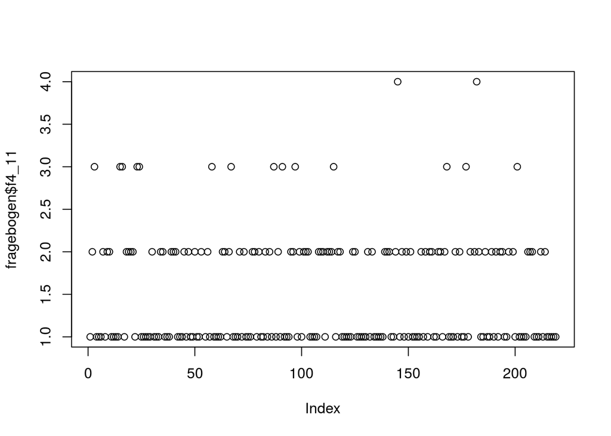

```r
# test ob Imputation statistisch erfolgreich

# Zum visuellen Vergleich wie gut KNN Algo funkt hat

essen_wohlbefinden = knn_fragebogen$f4_11
plot(fragebogen$f4_11)
```

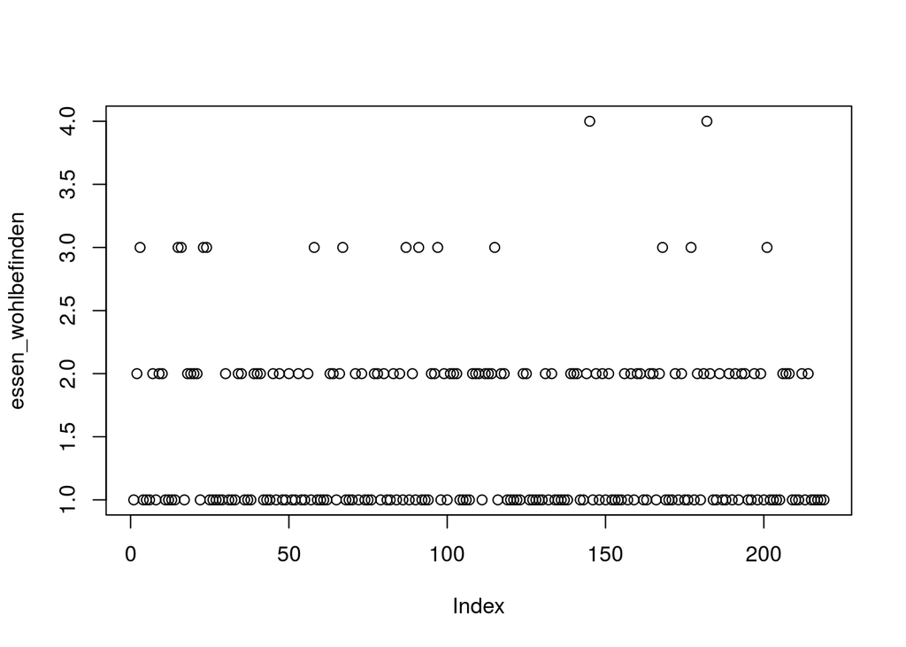

```r
plot(essen_wohlbefinden)
```

## Frage 1: Welchen Einfluss hat das Essen auf das Wohlbefinden der Gäste? (Stellen- wert des Essens im Vergleich zu den sonstigen Angeboten ROBINSON

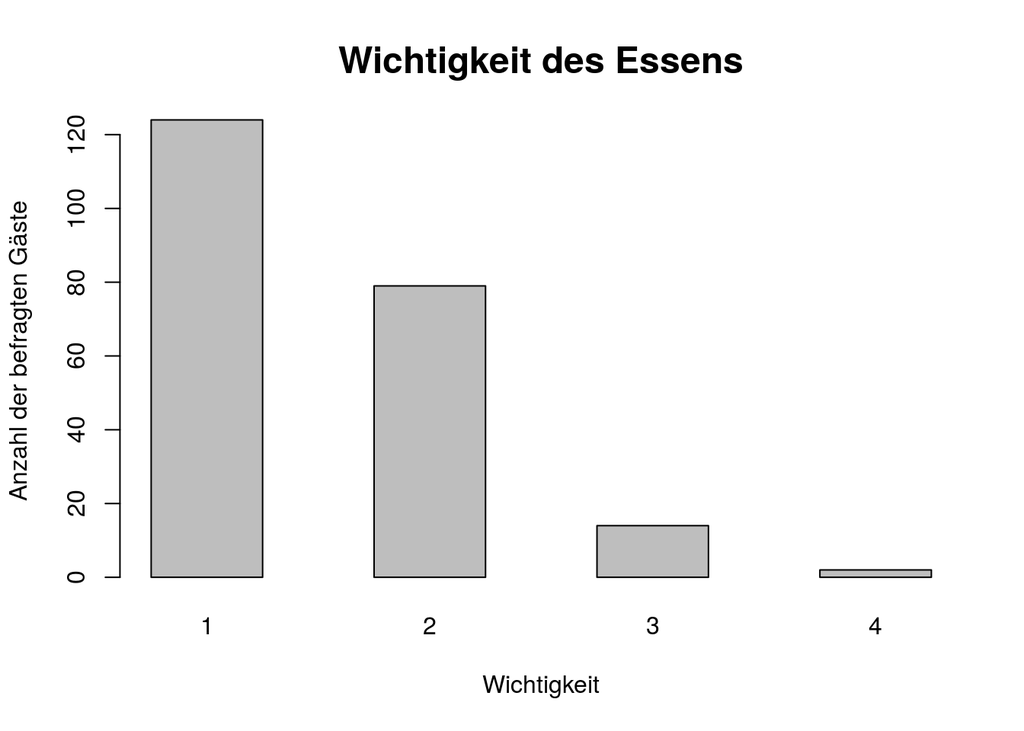

```r
#KOMMENTAR
#Prozentualer Anteil an Probanden, die Essen als Wichtig erachten

barplot(table(essen_wohlbefinden) , main = "Wichtigkeit des Essens",xlab = "Wichtigkeit", ylab = "Anzahl der befragten Gäste", space = 1, cex.axis = 1, cex.names = 1, cex.lab = 1, cex.main = 1.5)
```

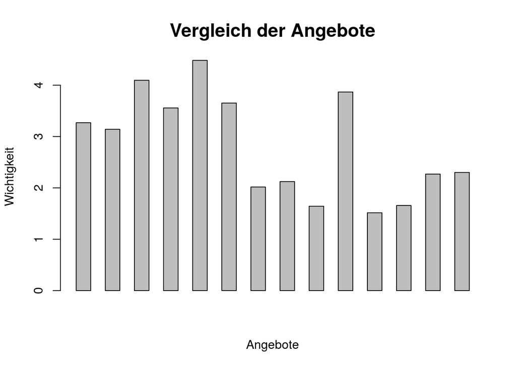

```r
# Essen ist den befragten Gästen sehr wichitg
MW4.1 <- mean(knn_fragebogen$f4_1)
MW4.2 <- mean(knn_fragebogen$f4_2)
MW4.3 <- mean(knn_fragebogen$f4_3)
MW4.4 <- mean(knn_fragebogen$f4_4)
MW4.5 <- mean(knn_fragebogen$f4_5)
MW4.6 <- mean(knn_fragebogen$f4_6)
MW4.7 <- mean(knn_fragebogen$f4_7)
MW4.8 <- mean(knn_fragebogen$f4_8)
MW4.9 <- mean(knn_fragebogen$f4_9)
MW4.10 <- mean(knn_fragebogen$f4_10)
MW4.11<- mean(knn_fragebogen$f4_11)
MW4.12<- mean(knn_fragebogen$f4_12)
MW4.13 <- mean(knn_fragebogen$f4_13)
MW4.14 <- mean(knn_fragebogen$f4_14)

MWVektorEssen <- c(MW4.1,MW4.2,MW4.3,MW4.4,MW4.5,MW4.6,MW4.7,MW4.8,MW4.9,MW4.10,MW4.11,MW4.12,MW4.13,MW4.14)
barplot(MWVektorEssen, main = "Vergleich der Angebote",xlab = "Angebote", ylab = "Wichtigkeit", space = 1, cex.axis = 1, cex.names = 1, cex.lab = 1, cex.main = 1.5)
```

**Angebot 11 (Essen) ist den befragten Gästen am wichtigsten im Vergleich zu dem restlichen Angebot**

## Frage 2: Ist ein Angebot von Bionahrung den Gästen wichtig/erwünscht/erwartet? (Wichtigkeit von Bionahrung)

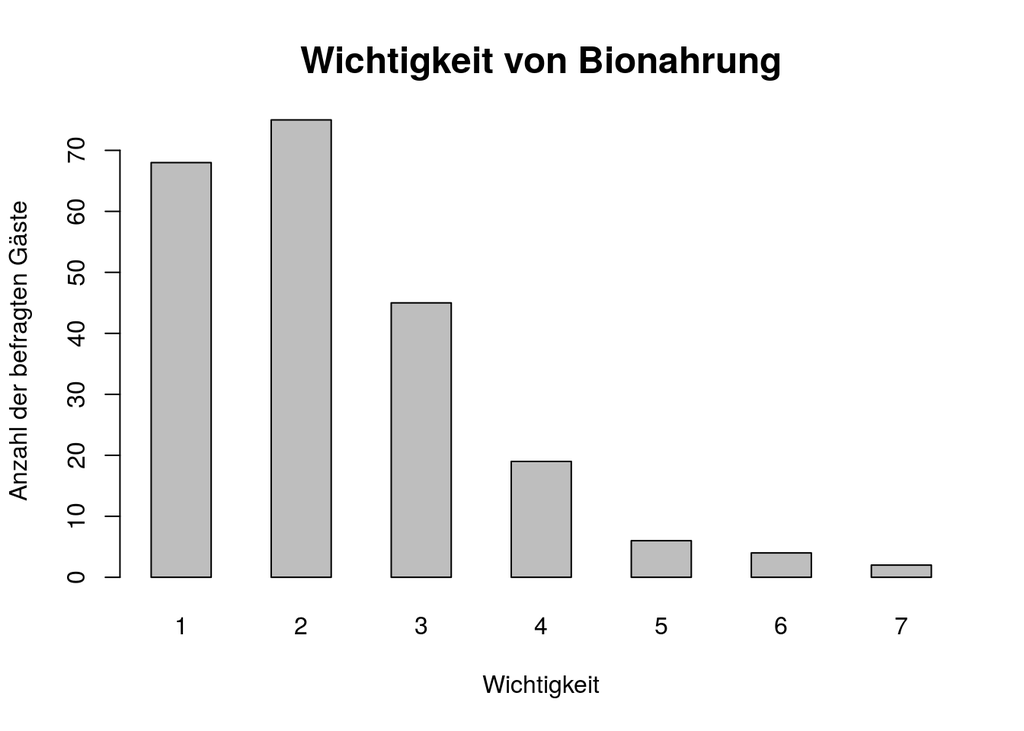

```r
essen_bionahrung = knn_fragebogen$f4_13
barplot(table(essen_bionahrung), main = "Wichtigkeit von Bionahrung",xlab = "Wichtigkeit", ylab = "Anzahl der befragten Gäste", space = 1, cex.axis = 1, cex.names = 1, cex.lab = 1, cex.main = 1.5)
```

**Bionahrung ist den Gästen wichtig**

## Frage 3: Was bedeutet Bio fu ̈r die G ̈aste? (Herausstellen der Elemente von Bion- ahrung und der Wichtigkeit dieser Elemente)

## Frage 4: Sind die G ̈aste bereit fu ̈r ein Angebot von Bionahrung einen Aufschlag zu zahlen? (Preissensitivit ̈at der G ̈aste fu ̈r ein zus ̈atzliches Angebot von Bionahrung)

```r
price_sensitivity = numericfragebogen$f17
price_sensitivity = as.data.table(price_sensitivity)
price_sensitivity = na.omit(price_sensitivity)


#Wie viele n's vor dem droppen von NA Reihen? --> 219
length(numericfragebogen$f17)
```

```
## [1] 219
```

```r
#Wie viele n's? --> 100
count(price_sensitivity)
```

```
## # A tibble: 1 x 1
##       n
##   <int>
## 1   100
```

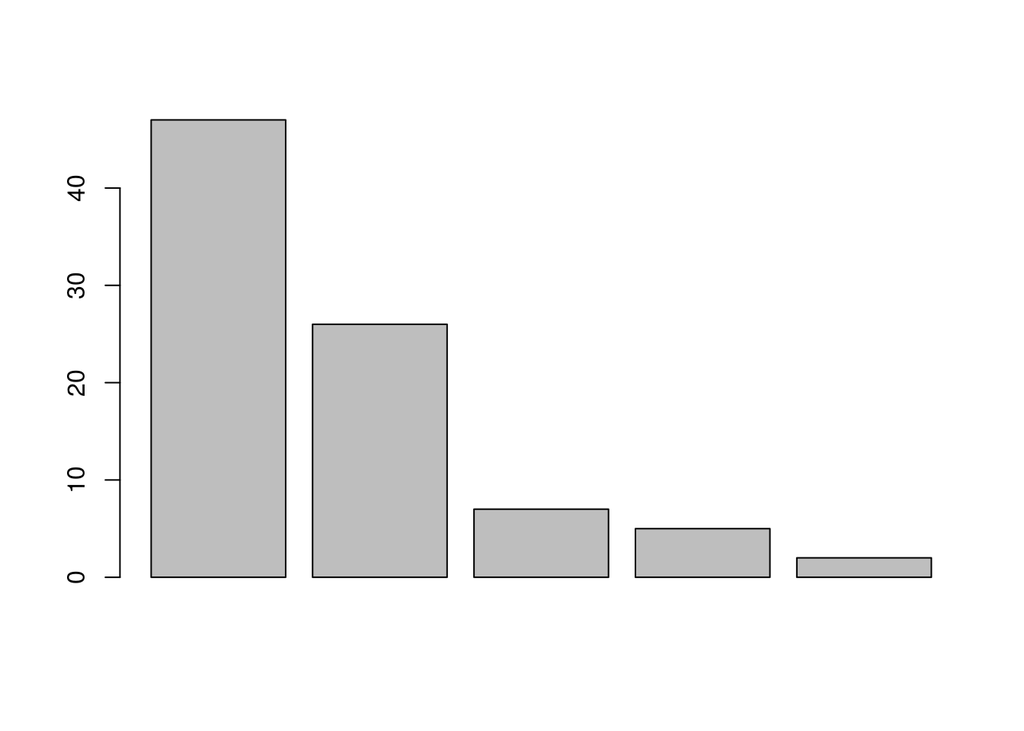

```r
#Wie viele würden überhaupt mehr bezahlen? --> 66 Personen
ps_0 = price_sensitivity[price_sensitivity>0, .N]

#Wie viele würden mehr als 3 % bezahlen? --> 47 Personen
ps_3 = price_sensitivity[price_sensitivity>3, .N]
u_ps_3 = ps_3 * 0.03


#Wie viele würden mehr als 5 % bezahlen? --> 26 Personen
ps_5 = price_sensitivity[price_sensitivity>5, .N]
u_ps_5 = ps_5 * 0.05

#Wie viele würden mehr als 10 % bezahlen? --> 7 Personen
ps_10 = price_sensitivity[price_sensitivity>10, .N]
u_ps_10 = ps_10 * 0.1

#Wie viele würden mehr als 15 % bezahlen? --> 5 Personen
ps_15 = price_sensitivity[price_sensitivity>15, .N]
u_ps_15 = ps_15 * 0.15

#Wie viele würden mehr als 20 % bezahlen? --> 2 Personen
ps_20 = price_sensitivity[price_sensitivity>20, .N]
u_ps_20 = ps_20 * 0.2

#Ergebnisse in einen Vektor packen
all_ps = c(ps_3, ps_5, ps_10, ps_15, ps_20)
all_u_ps = c(u_ps_3,u_ps_5,u_ps_10,u_ps_15,u_ps_20)

#barplot in absoluten Zahlen
barplot(all_ps)
```

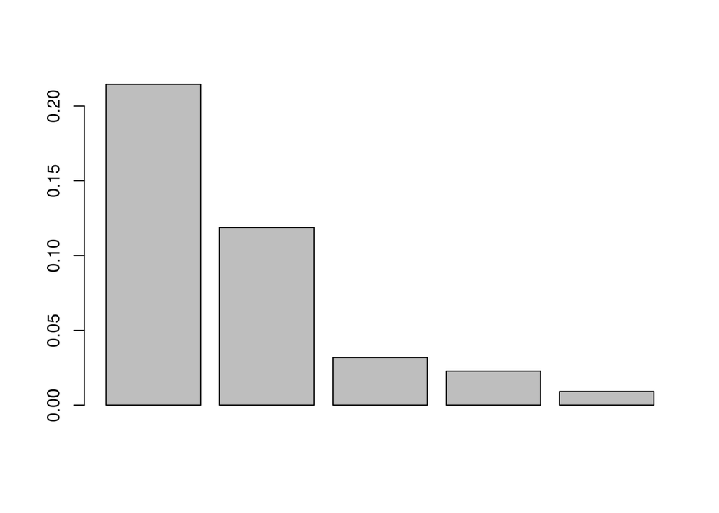

```r
#barplot in Prozenten, wir müssen davon ausgehen, dass diejenigen die nicht geantwortet haben, keinen Aufschlag zahlen würden
barplot(all_ps/length(numericfragebogen$f17))
```

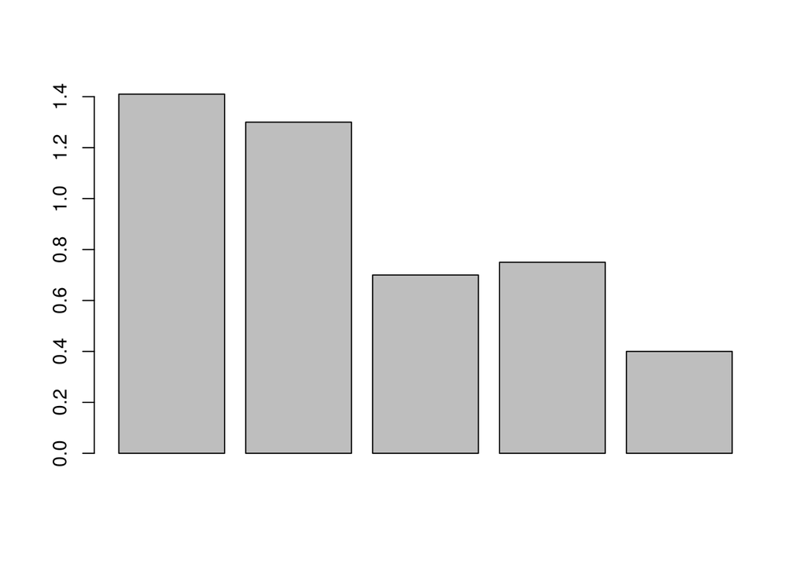

```r
#barplot Umsatz für jede Erhöhung --> Zeigt welche Prozenterhöhung sich lohnen würde wenn man die prozentuale Erhöhung und die Kaufbereitschaft der Kunden betrachtet
barplot(all_u_ps)
```

# Frage 5: Wem genau ist das Angebot von Bionahrung wichtig? Wie unterscheiden sich diese Personen? (Zielgruppenidentifikation bezüglich Bionahrung)

```r
# Annahme: Ab 3 oder kleiner ist Bio für die Probanden wichtig
#data.table(knn_fragebogen)
#bio = knn_fragebogen$f4_13
#bio_wichtig = bio[bio<=3]
#bio_wichtig = as.data.table(bio_wichtig)


# Leute die Bio mögen und und Demografische Daten
bio2 = numericfragebogen[numericfragebogen$f4_13<3,]
bio2 = select(bio2, -c(f3_1:f6_9))
bio2 = select(bio2, -c(f15_1:f19_10))
bio2 = select(bio2, -c(f8:f13_3))
#nicht brauchbar
bio2 = select(bio2, -c(ID:Ort))
bio2 = select(bio2, -c(f23_4))
#niemand hat das alter seines/ihres 4. Kindes angegeben
bio2 = select(bio2, -c(f24))




# das richtige K finden mit Elbow Method
```

## Frage 6: Bei welchen Lebensmittelarten ist das Angebot von Bio besonders wichtig /unwichtig? (Wichtigkeit von Bio bei unterschiedlichen Lebensmittelarten)

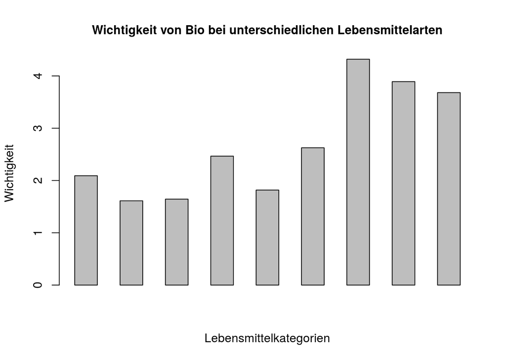

```r
MW16.1 <- mean(knn_fragebogen$f16_1)
MW16.2 <- mean(knn_fragebogen$f16_2)
MW16.3 <- mean(knn_fragebogen$f16_3)
MW16.4 <- mean(knn_fragebogen$f16_4)
MW16.5 <- mean(knn_fragebogen$f16_5)
MW16.6 <- mean(knn_fragebogen$f16_6)
MW16.7 <- mean(knn_fragebogen$f16_7)
MW16.8 <- mean(knn_fragebogen$f16_8)
MW16.9 <- mean(knn_fragebogen$f16_9)

MWVektorBionahrung <- c(MW16.1,MW16.2,MW16.3,MW16.4,MW16.5,MW16.6,MW16.7,MW16.8,MW16.9)


barplot(MWVektorBionahrung, main = "Wichtigkeit von Bio bei unterschiedlichen Lebensmittelarten",xlab = "Lebensmittelkategorien", ylab = "Wichtigkeit", space = 1, cex.axis = 1, cex.names = 1, cex.lab = 1, cex.main = 1)
```

**Bei Gemüse & Salat (2), Obst (3) und Fleischprodukten (5) ist Bio für die Gäste wichtig. Bei Süßigkeiten (7), Gewürzen (8) und bei den Getränken (9) eher nicht.**

# Hypothesen

## 1 Hypothese: Personen mit Kindern bevorzugen Bionahrung eher als Personen ohne Kinder.

H0: Personen mit Kindern bevorzugen Bionahrung nicht eher als Personen ohne Kinder. H1: Personen mit Kindern bevorzugen Bionahrung eher als Personen ohne Kinder.

```r
#Wie kommen wir an alle Personen die Kinder haben? --> Frage 2.3 sehr passend da bei der niedrigen prozentualen Anzahl an fehlenden Werten Reihen gedropped werden können.

# Annahme: Wer mit Familie kommt, kommt auch mit Kindern

# Frage 9
preferences_bio = as.data.table(fragebogen$f9)


# Frage 2
bio_children = as.data.table(fragebogen$f2)
#replacing 0 with NA
bio_children[bio_children == 0] <- NA

#datasets verbinden
merge_p_b = cbind(bio_children, preferences_bio)
#Spalten Namen ändern
colnames(merge_p_b) = c('bio_children','preferences_bio')

#wie viele NA's pro Spalte?
perc_na$f9.n #0.04 % NA
```

```
## [1] 0.00456621
```

```r
perc_na$f2.n #keine NA
```

```
## [1] 0
```

```r
#es kann bei so einer geringen Anzahl an NA's Reihen gedroped werden
merge_p_b_na = na.omit(merge_p_b)


#filtern nach denen die bio mögen
#bio_mögen_u.kinder = merge_p_b_na[merge_p_b_na$preferences_bio < 3 & merge_p_b_na$bio_children == 3]

####################

#Kinder neu definiert

kinder_bio_all = cbind(fragebogen$f23_1, fragebogen$f23_2, fragebogen$f23_3, fragebogen$f23_4, preferences_bio)
# neue spalte die zählt wie viele NA pro Reihe
kinder_bio_all$na_count <- apply(kinder_bio_all, 1, function(x) sum(is.na(x)))

kinder_bio_all =  as.data.table(kinder_bio_all)
colnames(kinder_bio_all) = c('1Ki','2Ki','3Ki','4Ki','bio','na_count')



# definiert df mit und ohne Kinder
# keine_kinder_mögen = kinder_bio_all[kinder_bio_all$na_count==4 & kinder_bio_all$bio < 3]
# keine_kinder_n_mögen = kinder_bio_all[kinder_bio_all$na_count==4 & kinder_bio_all$bio > 2]

# kinder und keine kinder und dann mittelwert von bio ermitteln
keine_kinder = kinder_bio_all[kinder_bio_all$na_count==4]
kinder = kinder_bio_all[kinder_bio_all$na_count!=4]

# drop na und dt erstellen
kinder_bio = as.data.table(kinder$bio)
kinder_bio = na.omit(kinder$bio)

keine_kinder_bio = as.data.table(keine_kinder$bio)


# mittelwert ermitteln
mean_k_b = mean(kinder_bio)
mean_kk_b = mean(data.matrix(keine_kinder_bio)) #mean funktioniert nicht immer mit dt

# t.test durchführen
t.test(kinder_bio, keine_kinder_bio)
```

```
##
##  Welch Two Sample t-test
##
## data:  kinder_bio and keine_kinder_bio
## t = -1.7248, df = 92.087, p-value = 0.08791
## alternative hypothesis: true difference in means is not equal to 0
## 95 percent confidence interval:
##  -0.54709540  0.03851365
## sample estimates:
## mean of x mean of y
##  2.097561  2.351852
```

```r
#--> Können H0 nicht verwerfen da p.value > alpha deshalb müssen wir bei der H0 hypo bleiben
```

## Hypothese: Robinson G ̈aste sind bereit fu ̈r Bionahrung einen Aufschlag zu zahlen.